# Aula 4 - Manipulando quase qualquer base

2023-01-29

# Entendendo datasets Wide e Long

Vamos carregar o tidyverse, já que ele contém os principais pacotes que veremos nessa aula, a saber, tidyr, tibble, dplyr e ggplot

```r
library(tidyverse)
```

Para compreender o que são datasets long e wide vamos usar os datasets do pacote {tidyr}. Um dataset pode apresentar e organizar dados de multiplas maneiras. Vejamos o dataset abaixo.

O dataset abaixo é chamado de dataset *tidy*, ou organizado.

```r
tidyr::table1
```

```
## # A tibble: 6 × 4
##   country      year  cases population
##   <chr>       <int>  <int>      <int>
## 1 Afghanistan  1999    745   19987071
## 2 Afghanistan  2000   2666   20595360
## 3 Brazil       1999  37737  172006362
## 4 Brazil       2000  80488  174504898
## 5 China        1999 212258 1272915272
## 6 China        2000 213766 1280428583
```

Já os datasets abaixo está no formato wide. Observem que o dataset table4a mede a informações de cases, e o dataset table4b mede as informações de population. Datasets wide são conhecidos por distribuirem suas informações horizontalmente. Nesse caso temos as informações de casos e de população medidas por ano em colunas.

```r
tidyr::table4a
```

```
## # A tibble: 3 × 3
##   country     `1999` `2000`
## * <chr>        <int>  <int>
## 1 Afghanistan    745   2666
## 2 Brazil       37737  80488
## 3 China       212258 213766
```

```r
tidyr::table4b
```

```
## # A tibble: 3 × 3
##   country         `1999`     `2000`
## * <chr>            <int>      <int>
## 1 Afghanistan   19987071   20595360
## 2 Brazil       172006362  174504898
## 3 China       1272915272 1280428583
```

```r
tidyr::table2
```

```
## # A tibble: 12 × 4
##    country      year type            count
##    <chr>       <int> <chr>           <int>
##  1 Afghanistan  1999 cases             745
##  2 Afghanistan  1999 population   19987071
##  3 Afghanistan  2000 cases            2666
##  4 Afghanistan  2000 population   20595360
##  5 Brazil       1999 cases           37737
##  6 Brazil       1999 population  172006362
##  7 Brazil       2000 cases           80488
##  8 Brazil       2000 population  174504898
##  9 China        1999 cases          212258
## 10 China        1999 population 1272915272
## 11 China        2000 cases          213766
## 12 China        2000 population 1280428583
```

Já o dataset table1 é chamado de tidy, ou organizado já que: 1. Cada variável tem sua própria coluna; 2. Cada observação tem sua própria linha; 3. Cada valor está em sua própria celula.

E como transformar um dataset para um formato tidy? Uma das possibilidades e a mais indicada é usando o pivoting. Voltemos a tablea4a.

```r
tidyr::table4a
```

```
## # A tibble: 3 × 3
##   country     `1999` `2000`
## * <chr>        <int>  <int>
## 1 Afghanistan    745   2666
## 2 Brazil       37737  80488
## 3 China       212258 213766
```

Como podemos tranformar esses dados em tidy data, ou dados organizados? A resposta é usando as funções de pivoting. Seja de pivot_longer() que transforma os dados em formato long, ou seja usando a pivot_wider que transforma os dados em formato wide.

```r
tidyr::table4a %>% # dataset em formato wide
  tidyr::pivot_longer(  #Função que transforma os dados em formato long
    c(`1999`, `2000`),  #Indicamos as colunas que serão empilhadas
    names_to = "year",  #Indicamos a coluna que receberá valor de classificação
    values_to = "cases" #Indicamos a coluna que receberá os valores
    )
```

```
## # A tibble: 6 × 3
##   country     year   cases
##   <chr>       <chr>  <int>
## 1 Afghanistan 1999     745
## 2 Afghanistan 2000    2666
## 3 Brazil      1999   37737
## 4 Brazil      2000   80488
## 5 China       1999  212258
## 6 China       2000  213766
```

Sempre que quisermos organizar um dataset em um formato long, usaremos a função tidyr:: pivot_longer.

```r
tidyr::table4b %>% #dataset em formato wide
  tidyr::pivot_longer(        #Função que transforma os dados em formato long
    c(`1999`, `2000`), #Indicamos as colunas que serão empilhadas
    names_to = "year", #Indicamos a coluna que receberá valor de classificação
    values_to = "population"#Indicamos a coluna que receberá os valores
  )
```

```
## # A tibble: 6 × 3
##   country     year  population
##   <chr>       <chr>      <int>
## 1 Afghanistan 1999    19987071
## 2 Afghanistan 2000    20595360
## 3 Brazil      1999   172006362
## 4 Brazil      2000   174504898
## 5 China       1999  1272915272
## 6 China       2000  1280428583
```

Um outro exemplo de datasets que não estão em formato tidy é o dataset table2. Nesse caso não temos uma variável para cada coluna, já que a coluna type mede o nome da variável e a coluna count o valor observado da variável.

```r
tidyr::table2
```

```
## # A tibble: 12 × 4
##    country      year type            count
##    <chr>       <int> <chr>           <int>
##  1 Afghanistan  1999 cases             745
##  2 Afghanistan  1999 population   19987071
##  3 Afghanistan  2000 cases            2666
##  4 Afghanistan  2000 population   20595360
##  5 Brazil       1999 cases           37737
##  6 Brazil       1999 population  172006362
##  7 Brazil       2000 cases           80488
##  8 Brazil       2000 population  174504898
##  9 China        1999 cases          212258
## 10 China        1999 population 1272915272
## 11 China        2000 cases          213766
## 12 China        2000 population 1280428583
```

```r
tidyr::table2 %>% #dataset n formato long
  tidyr::pivot_wider( # função que transforma os dados no formato wide
    names_from = type, # coluna que empilha o nome das variáveis
    values_from = count # coluna que empilha o valor observado das variáveis
              )
```

```
## # A tibble: 6 × 4
##   country      year  cases population
##   <chr>       <int>  <int>      <int>
## 1 Afghanistan  1999    745   19987071
## 2 Afghanistan  2000   2666   20595360
## 3 Brazil       1999  37737  172006362
## 4 Brazil       2000  80488  174504898
## 5 China        1999 212258 1272915272
## 6 China        2000 213766 1280428583
```

### Revisão

Importe o dataset dados_b3_2010_2022.csv; Remova a 1° coluna; Transforme o dataset para o formato tidy;

```r
dados_b3_2010_2022.csv <- readr::read_csv("https://raw.githubusercontent.com/BaruqueRodrigues/Curso-de-R/master/dados/dados_b3_2010_2022.csv")
```

```
## ──────────────────────────────────────────────────────── Delimiter: "," chr
## (1): ticker dbl (2): ...1, ret_adjusted_prices date (1): ref_date
```

```r
dados_b3_2010_2022.csv %>%
  select(-1) %>%
  tidyr::pivot_wider(names_from = ticker,
              values_from = ret_adjusted_prices)
```

```
## # A tibble: 2,480 × 70
##    ref_date     ALPA4.SA ABEV3.SA AMER3.SA B3SA3.SA BPAN4.SA BRML3.SA BBDC3.SA
##    <date>          <dbl>    <dbl>    <dbl>    <dbl>    <dbl>    <dbl>    <dbl>
##  1 2010-01-04 NA         NA       NA       NA       NA       NA       NA
##  2 2010-01-05  0.00348    0.00588 -0.0239   0.00386  0.0432   0.0185  -0.0138
##  3 2010-01-06 -0.00260    0.0102   0.0110   0.0377   0.0216   0.0455  -0.00589
##  4 2010-01-07  0.0104     0.00470  0.0113   0.0237   0.0265  -0.0130  -0.00230
##  5 2010-01-08  0.0103    -0.00192 -0.0239  -0.0232   0.0137  -0.00881  0.00132
##  6 2010-01-11  0.000426  -0.0122  -0.00905  0.00890  0.0339  -0.0173  -0.00329
##  7 2010-01-12  0          0.00649 -0.0118  -0.00955 -0.0205  -0.0104   0.00496
##  8 2010-01-13  0.0122     0.0129   0.00969  0.0163  -0.00837 -0.00137  0.00658
##  9 2010-01-14  0.0000840  0.0143  -0.00156  0       -0.0186  -0.0499  -0.0131
## 10 2010-01-15  0.00420   -0.00170 -0.0275  -0.00584 -0.0198   0.0130  -0.0225
## # … with 2,470 more rows, and 62 more variables: BBDC4.SA <dbl>,
## #   BRAP4.SA <dbl>, BBAS3.SA <dbl>, BRKM5.SA <dbl>, BRFS3.SA <dbl>,
## #   CCRO3.SA <dbl>, CMIG4.SA <dbl>, CIEL3.SA <dbl>, CPLE6.SA <dbl>,
## #   CSAN3.SA <dbl>, CPFE3.SA <dbl>, CYRE3.SA <dbl>, DXCO3.SA <dbl>,
## #   ECOR3.SA <dbl>, ELET3.SA <dbl>, ELET6.SA <dbl>, EMBR3.SA <dbl>,
## #   ENBR3.SA <dbl>, ENGI11.SA <dbl>, ENEV3.SA <dbl>, EGIE3.SA <dbl>,
## #   EQTL3.SA <dbl>, EZTC3.SA <dbl>, FLRY3.SA <dbl>, GGBR4.SA <dbl>, …
```

Transforme o dataset abaixo para o formato tidy()

```r
people <- tribble(
  ~name,             ~names,  ~values,
  #-----------------|--------|------
  "Phillip Woods",   "age",       45,
  "Phillip Woods",   "height",   186,
  "Phillip Woods",   "age",       50,
  "Jessica Cordero", "age",       37,
  "Jessica Cordero", "height",   156
)
```

```r
people %>%
  tidyr::pivot_wider(names_from = names,
              values_from = values)
```

```
## # A tibble: 2 × 3
##   name            age       height
##   <chr>           <list>    <list>
## 1 Phillip Woods   <dbl [2]> <dbl [1]>
## 2 Jessica Cordero <dbl [1]> <dbl [1]>
```

O dataset acima contém colunas com valores listados. Guarde essa informação, em breve veremos como lidar com esses dados.

## Separando e Juntando dados

Alguns datasets tem particularidades,onde os valores das colunas ficam aninhandos a função tidyr::separate()

```r
tidyr::table3
```

```
## # A tibble: 6 × 3
##   country      year rate
## * <chr>       <int> <chr>
## 1 Afghanistan  1999 745/19987071
## 2 Afghanistan  2000 2666/20595360
## 3 Brazil       1999 37737/172006362
## 4 Brazil       2000 80488/174504898
## 5 China        1999 212258/1272915272
## 6 China        2000 213766/1280428583
```

Veja a coluna rate da table3. Ela contém os valores de cases e population, entretanto essa coluna contém 2 variáveis diferentes, e para transformarmos esses dados em formato tidy precisamos separar essas colunas.

```r
tidyr::table3 %>% # dataset com uma coluna que precisa ser separado
  tidyr::separate( # função que irá separar a coluna
    rate, # coluna que será separada
    sep = "/", # argumento que deve ser separado
    into = c("cases", "population") # nome das colunas que serão separadas
  )
```

```
## # A tibble: 6 × 4
##   country      year cases  population
##   <chr>       <int> <chr>  <chr>
## 1 Afghanistan  1999 745    19987071
## 2 Afghanistan  2000 2666   20595360
## 3 Brazil       1999 37737  172006362
## 4 Brazil       2000 80488  174504898
## 5 China        1999 212258 1272915272
## 6 China        2000 213766 1280428583
```

Podemos usar a função separate de diversar formas, de maneira quase ilimitada, como o caso abaixo que separamos a coluna year. no segundo digito

```r
tidyr::table3 %>% #dataset com uma coluna que precisa ser separado
  tidyr::separate(# função que irá separar a coluna
    year, # coluna que será separada
    into = c("century", "year"), # nome das colunas que serão separadas
    sep = 2 # argumento que deve ser separado
    )
```

```
## # A tibble: 6 × 4
##   country     century year  rate
##   <chr>       <chr>   <chr> <chr>
## 1 Afghanistan 19      99    745/19987071
## 2 Afghanistan 20      00    2666/20595360
## 3 Brazil      19      99    37737/172006362
## 4 Brazil      20      00    80488/174504898
## 5 China       19      99    212258/1272915272
## 6 China       20      00    213766/1280428583
```

Caso tenhamos que juntar valores que estão separados em colunas diferente podemos usar a função tidyr::unite() que funciona no inverso da função separate(). Observem o dataset abaixo. ele tem a coluna century e year, entretanto essas medidas são pouco usais, geralmente temos essas duas unidades juntas.

```r
tidyr::table5
```

```
## # A tibble: 6 × 4
##   country     century year  rate
## * <chr>       <chr>   <chr> <chr>
## 1 Afghanistan 19      99    745/19987071
## 2 Afghanistan 20      00    2666/20595360
## 3 Brazil      19      99    37737/172006362
## 4 Brazil      20      00    80488/174504898
## 5 China       19      99    212258/1272915272
## 6 China       20      00    213766/1280428583
```

Para juntar os dados utilizaremos a função tidyr::unite()

```r
table5 %>% # dataset que terá colunas ajuntadas
  unite( # função que juntará as colunas
    ano_completo, # nova coluna
    century, year, #colunas que serão juntas
    sep = "" #separador
    )
```

```
## # A tibble: 6 × 3
##   country     ano_completo rate
##   <chr>       <chr>        <chr>
## 1 Afghanistan 1999         745/19987071
## 2 Afghanistan 2000         2666/20595360
## 3 Brazil      1999         37737/172006362
## 4 Brazil      2000         80488/174504898
## 5 China       1999         212258/1272915272
## 6 China       2000         213766/1280428583
```

### Revisão

```r
 pedidos <- readr::read_csv(

    "https://raw.githubusercontent.com/BaruqueRodrigues/Curso-de-R/master/dados/pedidos.csv")
```

```
## ──────────────────────────────────────────────────────── Delimiter: "," chr
## (1): descricao_por_pedido dbl (2): ...1, no_pedido
```

A resolução

```r
pedidos %>%
  select(-1) %>% # removo a primeira coluna
  separate(descricao_por_pedido,
           into = c("item_1", #separo a coluna em 5 itens
                    "item_2",
                    "item_3",
                    "item_4",
                    "item_5"),
           sep = ","#indico que o separador é uma virgula
           ) %>%
  #Transformo os dados em um formato long
  pivot_longer(c(item_1:item_5),
               names_to = "item_pedido",
               values_to = "desc_pedido")
```

```
## # A tibble: 625 × 3
##    no_pedido item_pedido desc_pedido
##        <dbl> <chr>       <chr>
##  1         1 item_1      3 mistos
##  2         1 item_2      <NA>
##  3         1 item_3      <NA>
##  4         1 item_4      <NA>
##  5         1 item_5      <NA>
##  6         2 item_1      1 misto
##  7         2 item_2      <NA>
##  8         2 item_3      <NA>
##  9         2 item_4      <NA>
## 10         2 item_5      <NA>
## # … with 615 more rows
```

### Lidando com missing data

Existem 3 funções poderosas que podemos usar para lidar com dados ausentes são elas drop_na() que remove os casos com o valor NA; fill() que preenche valores NA com os valores númericos mais próximos ; replace_na() que substitui os valores NA por valores determinados pelo operador.

Vamos usar o dataset pedidos usado na revisão para exemplificar o uso de algumas dessas funções.

```r
pedidos_final <- pedidos %>%
  select(-1) %>%
  separate(descricao_por_pedido,
           into = c("item_1",
                    "item_2",
                    "item_3",
                    "item_4",
                    "item_5"),
           sep = ",") %>%
  pivot_longer(c(item_1:item_5),
               names_to = "item_pedido",
               values_to = "desc_pedido")
pedidos_final
```

```
## # A tibble: 625 × 3
##    no_pedido item_pedido desc_pedido
##        <dbl> <chr>       <chr>
##  1         1 item_1      3 mistos
##  2         1 item_2      <NA>
##  3         1 item_3      <NA>
##  4         1 item_4      <NA>
##  5         1 item_5      <NA>
##  6         2 item_1      1 misto
##  7         2 item_2      <NA>
##  8         2 item_3      <NA>
##  9         2 item_4      <NA>
## 10         2 item_5      <NA>
## # … with 615 more rows
```

A função drop_na() lida com dados ausentes removendo eles do dataset

```r
pedidos_final %>%
  drop_na()
```

```
## # A tibble: 197 × 3
##    no_pedido item_pedido desc_pedido
##        <dbl> <chr>       <chr>
##  1         1 item_1      "3 mistos"
##  2         2 item_1      "1 misto"
##  3         3 item_1      "1 x-katita"
##  4         4 item_1      "2 choricarnes"
##  5         5 item_1      "1 misto"
##  6         6 item_1      "2 carnes"
##  7         6 item_2      " 1 x-katita"
##  8         7 item_1      "1 carne"
##  9         8 item_1      "2 mistos"
## 10         8 item_2      " 1 coração"
## # … with 187 more rows
```

A função fill() vai preencher os valores ausentes com um valor da coluna usando o valor mais próximo do dado ausente. Entretanto só funciona com dados numéricos

```r
sales <- tibble::tribble(
  ~quarter, ~year, ~sales,
  "Q1",    2000,    66013,
  "Q2",      NA,    69182,
  "Q3",      NA,    53175,
  "Q4",      NA,    21001,
  "Q1",    2001,    46036,
  "Q2",      NA,    58842,
  "Q3",      NA,    44568,
  "Q4",      NA,    50197,
  "Q1",    2002,    39113,
  "Q2",      NA,    41668,
  "Q3",      NA,    30144,
  "Q4",      NA,    52897,
  "Q1",    2004,    32129,
  "Q2",      NA,    67686,
  "Q3",      NA,    31768,
  "Q4",      NA,    49094
)

sales
```

```
## # A tibble: 16 × 3
##    quarter  year sales
##    <chr>   <dbl> <dbl>
##  1 Q1       2000 66013
##  2 Q2         NA 69182
##  3 Q3         NA 53175
##  4 Q4         NA 21001
##  5 Q1       2001 46036
##  6 Q2         NA 58842
##  7 Q3         NA 44568
##  8 Q4         NA 50197
##  9 Q1       2002 39113
## 10 Q2         NA 41668
## 11 Q3         NA 30144
## 12 Q4         NA 52897
## 13 Q1       2004 32129
## 14 Q2         NA 67686
## 15 Q3         NA 31768
## 16 Q4         NA 49094
```

```r
sales %>%
  fill(year)
```

```
## # A tibble: 16 × 3
##    quarter  year sales
##    <chr>   <dbl> <dbl>
##  1 Q1       2000 66013
##  2 Q2       2000 69182
##  3 Q3       2000 53175
##  4 Q4       2000 21001
##  5 Q1       2001 46036
##  6 Q2       2001 58842
##  7 Q3       2001 44568
##  8 Q4       2001 50197
##  9 Q1       2002 39113
## 10 Q2       2002 41668
## 11 Q3       2002 30144
## 12 Q4       2002 52897
## 13 Q1       2004 32129
## 14 Q2       2004 67686
## 15 Q3       2004 31768
## 16 Q4       2004 49094
```

A função replace_na() vai substituir os dados ausentes por valores especificados.

```r
pedidos_final %>%
  replace_na(# função que vai substituir NA pelo valor desejado
    list( # usamos a função list pois podemos inserir várias colunas
      desc_pedido = "item_ausente" #indicando o substituto por coluna
      )
    )
```

```
## # A tibble: 625 × 3
##    no_pedido item_pedido desc_pedido
##        <dbl> <chr>       <chr>
##  1         1 item_1      3 mistos
##  2         1 item_2      item_ausente
##  3         1 item_3      item_ausente
##  4         1 item_4      item_ausente
##  5         1 item_5      item_ausente
##  6         2 item_1      1 misto
##  7         2 item_2      item_ausente
##  8         2 item_3      item_ausente
##  9         2 item_4      item_ausente
## 10         2 item_5      item_ausente
## # … with 615 more rows
```

## Transformando vetores de texto em datasets

Muitas vezes recebemos dados em formato de lista, ou formato textual e precisamos transforma-los para um formato de dataset. Uma das formas mais simples e robustas de fazer essa transformação é usando a função tibble::enframe(). Exemplificaremos usando os dados abaixo.

```r
dados_lista <- list(times = c("flamengo", "fluminense", "vasco", "botafogo"),
     titulos_liberta = c(2, "virgem das americas", 1, "bairro"),
     copas_br = c(3, 1, 1, "bairro"),
     brasileiros = c(8,4,4,1))
```

```r
dados_lista
```

```
## $times
## [1] "flamengo"   "fluminense" "vasco"      "botafogo"
##
## $titulos_liberta
## [1] "2"                   "virgem das americas" "1"
## [4] "bairro"
##
## $copas_br
## [1] "3"      "1"      "1"      "bairro"
##
## $brasileiros
## [1] 8 4 4 1
```

Utilizando a função enframe forçamos a lista em um formato de dataset. Entretanto os dados não estão no formato tidy, e temos valores em formato de list na coluna value.

```r
dados_lista %>%
  enframe()
```

```
## # A tibble: 4 × 2
##   name            value
##   <chr>           <list>
## 1 times           <chr [4]>
## 2 titulos_liberta <chr [4]>
## 3 copas_br        <chr [4]>
## 4 brasileiros     <dbl [4]>
```

O primeiro passo para lidar com esses dados é transformar os dados em formato tidy, usando a função tidyr::pivot_wider.

```r
dados_lista %>% #lista
  enframe() %>% #função que transforma os dados em formato dataset
  pivot_wider( #função que transforma os dados em formato wide
    names_from = name,
    values_from = value)
```

```
## # A tibble: 1 × 4
##   times     titulos_liberta copas_br  brasileiros
##   <list>    <list>          <list>    <list>
## 1 <chr [4]> <chr [4]>       <chr [4]> <dbl [4]>
```

Agora temos um dataset em formato tidy, entretanto ainda temos os valores em lista. Para lidar com esses tipos de dados usamos as funções da família unnest(), onde a função unnest_longer() tira os dados em formato de lista empilhando os valores em linha, e a função unnest_wider tira os dados de formato de lista espalhando em multiplas colunas.

```r
dados_lista %>%
  enframe() %>%
  pivot_wider(names_from = name,
              values_from = value) %>%
  unnest_longer(c(times:brasileiros))
```

```
## # A tibble: 4 × 4
##   times      titulos_liberta     copas_br brasileiros
##   <chr>      <chr>               <chr>          <dbl>
## 1 flamengo   2                   3                  8
## 2 fluminense virgem das americas 1                  4
## 3 vasco      1                   1                  4
## 4 botafogo   bairro              bairro             1
```

### Eninhando Dados

Em alguns casos precisamos eninhar dados, ou seja passar uma série de colunas pra dentro de uma coluna, para isso usamos a função nest().

No caso abaixo criaremos uma coluna chamada data que criará uma coluna que vai conter um dataset com todas as informações para uma coluna. Utilizaremos o dataset ggplot2::mpg para exemplificar.

```r
mpg %>% glimpse()
```

```
## Rows: 234
## Columns: 11
## $ manufacturer <chr> "audi", "audi", "audi", "audi", "audi", "audi", "audi", "…
## $ model        <chr> "a4", "a4", "a4", "a4", "a4", "a4", "a4", "a4 quattro", "…
## $ displ        <dbl> 1.8, 1.8, 2.0, 2.0, 2.8, 2.8, 3.1, 1.8, 1.8, 2.0, 2.0, 2.…
## $ year         <int> 1999, 1999, 2008, 2008, 1999, 1999, 2008, 1999, 1999, 200…
## $ cyl          <int> 4, 4, 4, 4, 6, 6, 6, 4, 4, 4, 4, 6, 6, 6, 6, 6, 6, 8, 8, …
## $ trans        <chr> "auto(l5)", "manual(m5)", "manual(m6)", "auto(av)", "auto…
## $ drv          <chr> "f", "f", "f", "f", "f", "f", "f", "4", "4", "4", "4", "4…
## $ cty          <int> 18, 21, 20, 21, 16, 18, 18, 18, 16, 20, 19, 15, 17, 17, 1…
## $ hwy          <int> 29, 29, 31, 30, 26, 26, 27, 26, 25, 28, 27, 25, 25, 25, 2…
## $ fl           <chr> "p", "p", "p", "p", "p", "p", "p", "p", "p", "p", "p", "p…
## $ class        <chr> "compact", "compact", "compact", "compact", "compact", "c…
```

```r
ggplot2::mpg %>%
  nest(#função que eninha os dados
    data = -model)
```

```
## # A tibble: 38 × 2
##    model              data
##    <chr>              <list>
##  1 a4                 <tibble [7 × 10]>
##  2 a4 quattro         <tibble [8 × 10]>
##  3 a6 quattro         <tibble [3 × 10]>
##  4 c1500 suburban 2wd <tibble [5 × 10]>
##  5 corvette           <tibble [5 × 10]>
##  6 k1500 tahoe 4wd    <tibble [4 × 10]>
##  7 malibu             <tibble [5 × 10]>
##  8 caravan 2wd        <tibble [11 × 10]>
##  9 dakota pickup 4wd  <tibble [9 × 10]>
## 10 durango 4wd        <tibble [7 × 10]>
## # … with 28 more rows
```

Cada linha da coluna data contém um dataset filtrado para coluna model. Ou seja temos um dataset que contém 38 datasets filtrados, cada um para um modelo.

A partir de dados eninhados podemos fazer multiplas análises, já que dentro da coluna de um tibble qualquer elemento pode ser guardado.  
Podemos guardar modelos de regressão

```r
mpg %>%
  nest(data = -model) %>%
  mutate(lm_model = map(data, ~lm(hwy~cty+cyl, data =.)))
```

```
## # A tibble: 38 × 3
##    model              data               lm_model
##    <chr>              <list>             <list>
##  1 a4                 <tibble [7 × 10]>  <lm>
##  2 a4 quattro         <tibble [8 × 10]>  <lm>
##  3 a6 quattro         <tibble [3 × 10]>  <lm>
##  4 c1500 suburban 2wd <tibble [5 × 10]>  <lm>
##  5 corvette           <tibble [5 × 10]>  <lm>
##  6 k1500 tahoe 4wd    <tibble [4 × 10]>  <lm>
##  7 malibu             <tibble [5 × 10]>  <lm>
##  8 caravan 2wd        <tibble [11 × 10]> <lm>
##  9 dakota pickup 4wd  <tibble [9 × 10]>  <lm>
## 10 durango 4wd        <tibble [7 × 10]>  <lm>
## # … with 28 more rows
```

Podemos também printar essas multiplas regressões e entender como cada regressão perfoma para o tipo de modelo

```r
mpg %>%
  nest(data =-model) %>%
  mutate(lm_model = map(data, ~lm(hwy~cty+cyl, data =.)),
         lm_model = map(lm_model, broom::tidy)
         ) %>%
  unnest(lm_model)
```

```
## # A tibble: 114 × 7
##    model              data              term   estim…¹ std.e…² stati…³   p.value
##    <chr>              <list>            <chr>    <dbl>   <dbl>   <dbl>     <dbl>
##  1 a4                 <tibble [7 × 10]> (Inte…  31.7     7.75    4.09    0.0150
##  2 a4                 <tibble [7 × 10]> cty      0.192   0.299   0.643   0.555
##  3 a4                 <tibble [7 × 10]> cyl     -1.45    0.521  -2.79    0.0495
##  4 a4 quattro         <tibble [8 × 10]> (Inte…  17.9     3.85    4.66    0.00555
##  5 a4 quattro         <tibble [8 × 10]> cty      0.510   0.163   3.13    0.0258
##  6 a4 quattro         <tibble [8 × 10]> cyl     -0.176   0.275  -0.642   0.549
##  7 a6 quattro         <tibble [3 × 10]> (Inte…  21.0   NaN     NaN     NaN
##  8 a6 quattro         <tibble [3 × 10]> cty      0.500 NaN     NaN     NaN
##  9 a6 quattro         <tibble [3 × 10]> cyl     -0.750 NaN     NaN     NaN
## 10 c1500 suburban 2wd <tibble [5 × 10]> (Inte…  -2.53    3.65   -0.693   0.538
## # … with 104 more rows, and abbreviated variable names ¹estimate, ²std.error,
## #   ³statistic
```

Observe que agora temos para cada modelo um intercepto, um beta para coluna cty e um beta para a coluna cyl.

Podemos fazer também um gráfico de dispersão para cada modelo.

```r
mpg %>%
  nest(data =-model) %>%
  mutate(grafico = map(data, ~ggplot(data = .,
                                     aes(x = hwy, y = cty))+
                         geom_point()))
```

```
## # A tibble: 38 × 3
##    model              data               grafico
##    <chr>              <list>             <list>
##  1 a4                 <tibble [7 × 10]>  <gg>
##  2 a4 quattro         <tibble [8 × 10]>  <gg>
##  3 a6 quattro         <tibble [3 × 10]>  <gg>
##  4 c1500 suburban 2wd <tibble [5 × 10]>  <gg>
##  5 corvette           <tibble [5 × 10]>  <gg>
##  6 k1500 tahoe 4wd    <tibble [4 × 10]>  <gg>
##  7 malibu             <tibble [5 × 10]>  <gg>
##  8 caravan 2wd        <tibble [11 × 10]> <gg>
##  9 dakota pickup 4wd  <tibble [9 × 10]>  <gg>
## 10 durango 4wd        <tibble [7 × 10]>  <gg>
## # … with 28 more rows
```

Observe que a coluna gráfico contém um objeto chamado gg. Se printarmos a coluna visualizaremos os gráficos

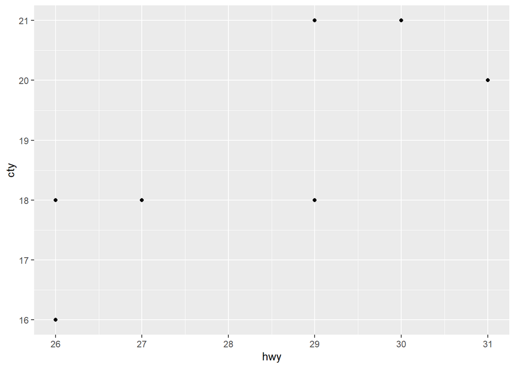

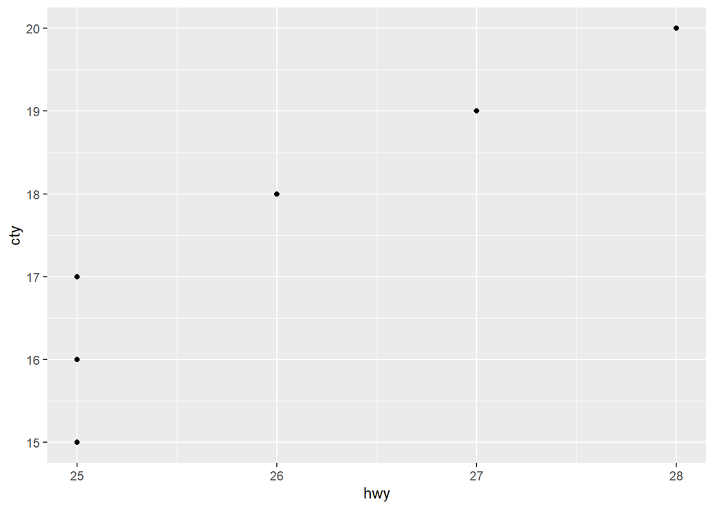

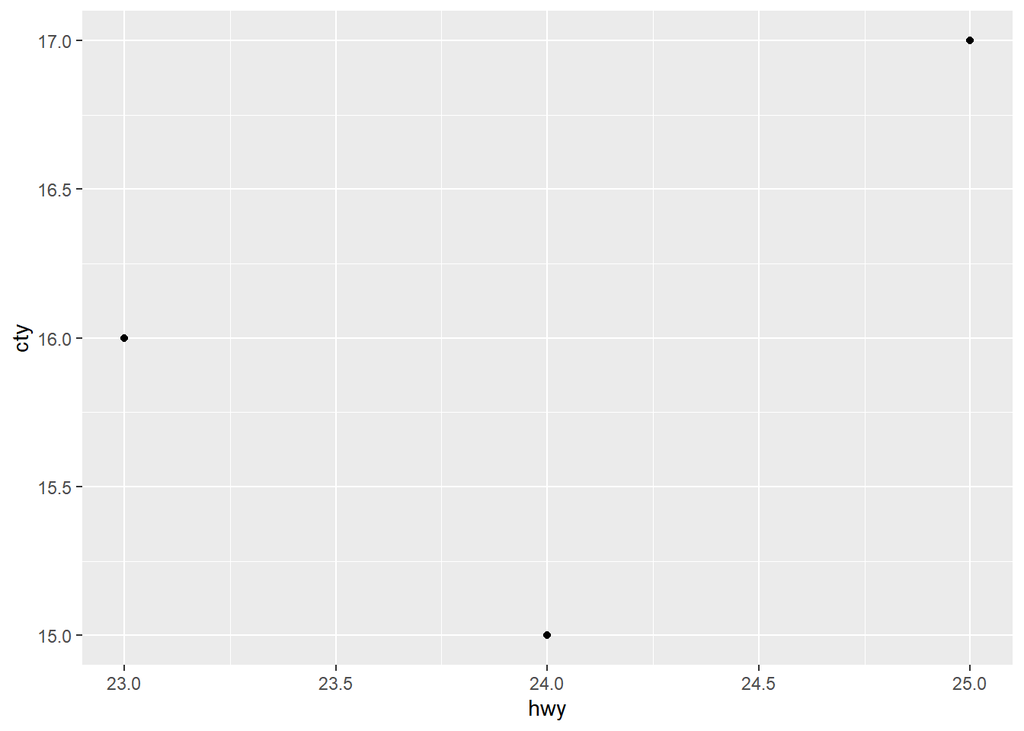

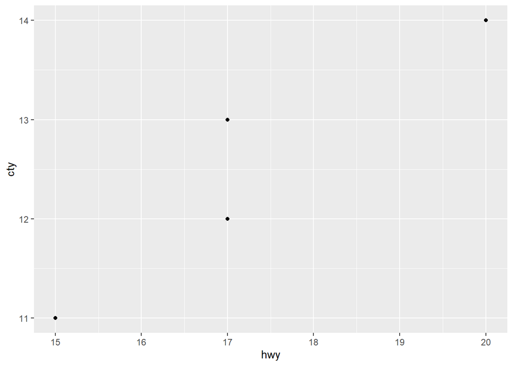

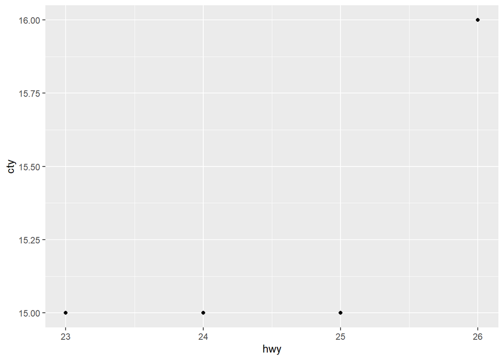

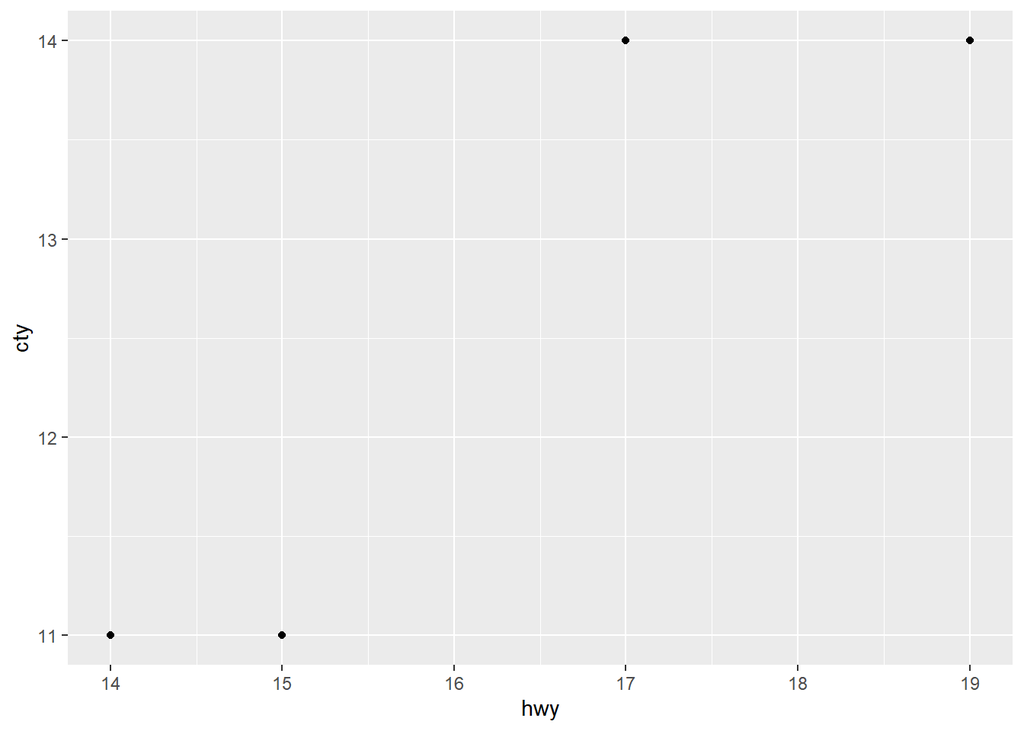

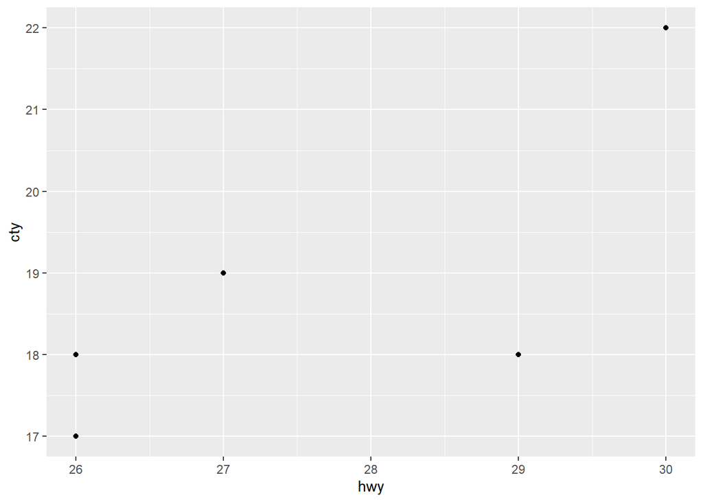

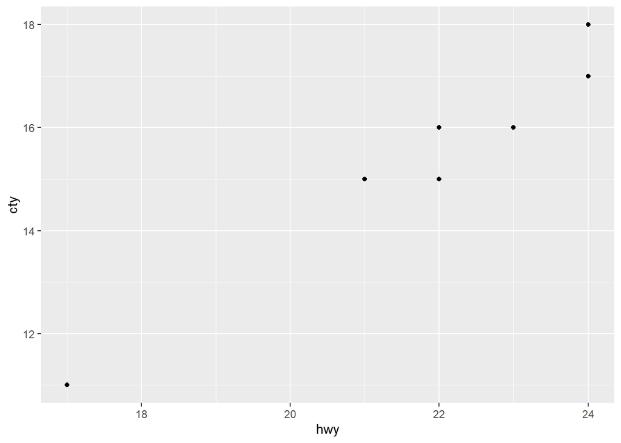

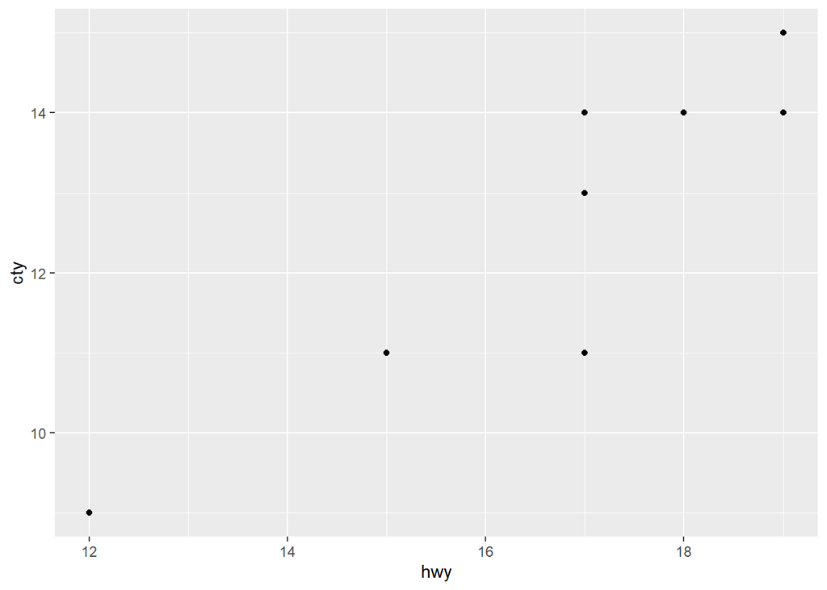

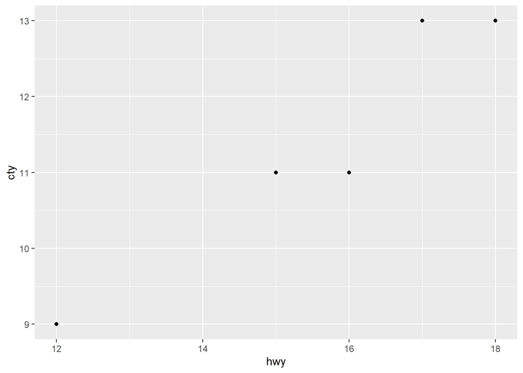

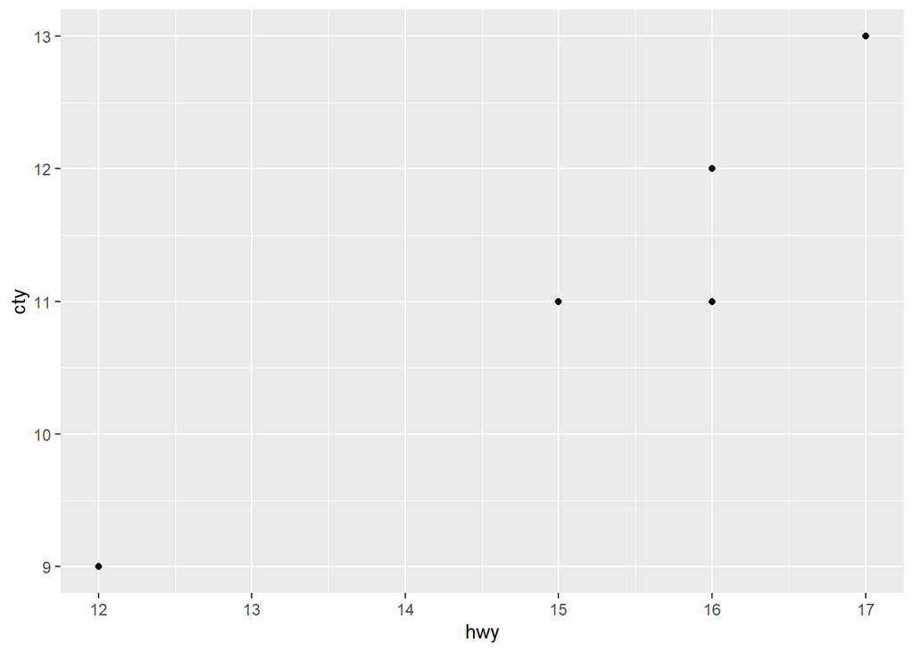

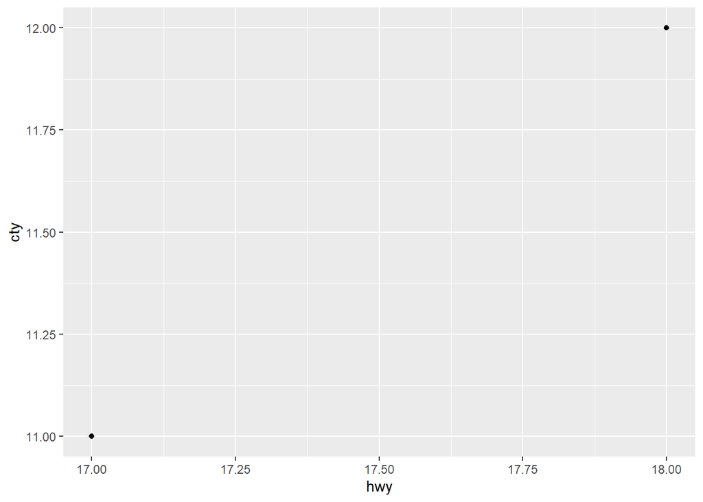

[26 more figures not shown]

```r
mpg %>%
  nest(-model) %>%
  mutate(grafico = map(data, ~ggplot(data = .,
                                     aes(x = hwy, y = cty))+
                         geom_point())) %>%
  pull(grafico)
```